# Grouping and nesting

Jae Yeon Kim

23 June, 2020

This workshop is for students who already have some experience with `dplyr` and `tidyr` and hope to upgrade their data wrangling skills in R.

# 1 Setup

- `pacman` is a great package management tool in R. (For more information, see [the package vignette](http://trinker.github.io/pacman/vignettes/Introduction_to_pacman.html).)
- Check your `dplyr` package is up-to-date by typing `packageVersion("dplyr")`. If the current installed version is less than 1.0, then update by typing `update.packages("dplyr")`. You may need to restart R to make it work.

# 2 Grouping

## 2.1 Grouped summaries

- Calculate the mean of `gdpPercap`.

```r
gapminder %>%
  group_by(continent) %>% #
  summarise(mean_gdp = mean(gdpPercap))
```

| continent | mean_gdp |
| --- | --- |
| Africa | 2193.755 |
| Americas | 7136.110 |
| Asia | 7902.150 |
| Europe | 14469.476 |
| Oceania | 18621.609 |

- Calculate multiple summary statistics.

```r
gapminder %>%
  group_by(continent) %>% #
  summarise(mean_gdp = mean(gdpPercap),
            count = n())
```

| continent | mean_gdp | count |
| --- | --- | --- |
| Africa | 2193.755 | 624 |
| Americas | 7136.110 | 300 |
| Asia | 7902.150 | 396 |
| Europe | 14469.476 | 360 |
| Oceania | 18621.609 | 24 |

- Other summary statistics
1. Measures of spread: `median(x)`, `sd(x)`, `IQR(x)`, `mad(x)` (the median absolute deviation)

```r
# The Interquartile Range = The Difference Between 75t and 25t Percentiles

gapminder %>%
  group_by(continent) %>% #
  summarise(IQR_gdp = IQR(gdpPercap))
```

| continent | IQR_gdp |
| --- | --- |
| Africa | 1616.170 |
| Americas | 4402.431 |
| Asia | 7492.262 |
| Europe | 13248.301 |
| Oceania | 8072.258 |

2. Measures of rank: `min(x)`, `quantile(x, 0.25)`, `max(x)`

```r
gapminder %>%
  group_by(continent) %>% #
  summarise(min_gdp = min(gdpPercap),
            max_gdp = max(gdpPercap))
```

| continent | min_gdp | max_gdp |
| --- | --- | --- |
| Africa | 241.1659 | 21951.21 |
| Americas | 1201.6372 | 42951.65 |
| Asia | 331.0000 | 113523.13 |
| Europe | 973.5332 | 49357.19 |
| Oceania | 10039.5956 | 34435.37 |

3. Measures of position: `first(x)`, `last(x)`, `nth(x, 2)`

```r
gapminder %>%
  group_by(continent) %>%
  summarise(first_gdp = first(gdpPercap),
            last_gdp = last(gdpPercap))
```

| continent | first_gdp | last_gdp |
| --- | --- | --- |
| Africa | 2449.0082 | 469.7093 |
| Americas | 5911.3151 | 11415.8057 |
| Asia | 779.4453 | 2280.7699 |
| Europe | 1601.0561 | 33203.2613 |
| Oceania | 10039.5956 | 25185.0091 |

```r
gapminder %>%
  group_by(continent) %>%
  arrange(gdpPercap) %>% # Adding arrange
  summarise(first_gdp = first(gdpPercap),
            last_gdp = last(gdpPercap))
```

| continent | first_gdp | last_gdp |
| --- | --- | --- |
| Africa | 241.1659 | 21951.21 |
| Americas | 1201.6372 | 42951.65 |
| Asia | 331.0000 | 113523.13 |
| Europe | 973.5332 | 49357.19 |
| Oceania | 10039.5956 | 34435.37 |

4. Measures of counts: `n(x)` (all rows), `sum(!is.na(x))` (only non-missing rows) = `n_distinct(x)`

```r
gapminder %>%
  group_by(continent) %>%
  summarise(ns = n())
```

| continent | ns |
| --- | --- |
| Africa | 624 |
| Americas | 300 |
| Asia | 396 |
| Europe | 360 |
| Oceania | 24 |

5. Counts and proportions of logical values: `sum(condition about x)` (the number of TRUEs in x), `mean(condition about x)` (the proportion of TRUEs in x)

```r
gapminder %>%
  group_by(continent) %>%
  summarise(rich_countries = mean(gdpPercap > 20000))
```

| continent | rich_countries |
| --- | --- |
| Africa | 0.004807692 |
| Americas | 0.050000000 |
| Asia | 0.111111111 |
| Europe | 0.261111111 |
| Oceania | 0.333333333 |

# 3 Nesting

## 3.1 Nest

The following example comes from [R for Data Science](https://r4ds.had.co.nz/many-models.html) by by Garrett Grolemund and Hadley Wickham.

- How can you run multiple models simultaneously? Using a nested data frame.
- Grouped data: each row = an observation
- Nested data: each row = a group

```r
nested <- gapminder %>%
  group_by(country, continent) %>%
  nest()

# country & continent (two grouping variables) + data
names(nested)
```

```
## [1] "country"   "continent" "data"
```

```r
# Data = listed columns

nested$data[[1]]
```

| year | lifeExp | pop | gdpPercap |
| --- | --- | --- | --- |
| 1952 | 28.801 | 8425333 | 779.4453 |
| 1957 | 30.332 | 9240934 | 820.8530 |
| 1962 | 31.997 | 10267083 | 853.1007 |
| 1967 | 34.020 | 11537966 | 836.1971 |
| 1972 | 36.088 | 13079460 | 739.9811 |
| 1977 | 38.438 | 14880372 | 786.1134 |
| 1982 | 39.854 | 12881816 | 978.0114 |
| 1987 | 40.822 | 13867957 | 852.3959 |
| 1992 | 41.674 | 16317921 | 649.3414 |
| 1997 | 41.763 | 22227415 | 635.3414 |

[output cut: 2 more lines]

- Custom function

```r
lm_model <- function(df) {

  lm(lifeExp ~ year, data = df)
}
```

- Apply function to the nested data

```r
# Apply m_model to the nested data

nested <- nested %>%
  mutate(models = map(data, lm_model)) # Add the list object as a new column

# Display the result by filtering rows

nested %>%
  filter(continent == "Asia")
```

| country | continent | data | models |
| --- | --- | --- | --- |
| Afghanistan | Asia |  |  |
| Bahrain | Asia |  |  |
| Bangladesh | Asia |  |  |
| Cambodia | Asia |  |  |
| China | Asia |  |  |
| Hong Kong, China | Asia |  |  |
| India | Asia |  |  |
| Indonesia | Asia |  |  |
| Iran | Asia |  |  |
| Iraq | Asia |  |  |

[output cut: 23 more lines]

## 3.2 Unnest

`glance()` function from `broom` package inspects the quality of a statistical model.

**Additional tips**

- `broom::glance(model)`: for evaluating model quality and/or complexity
- `broom::tidy(model)`: for extracting each coefficient in the model (the estimates + its variability)
- `broom::augment(model, data)`: for getting extra values (residuals, and influence statistics)

```r
glanced <- nested %>%
  mutate(glance = map(models, broom::glance))
```

`unnest()` unpacks the list objects stored in glance column

```r
glanced %>%
  unnest(glance) %>%
  arrange(BIC) # Low to High; Lower BIC indicates a better model fit
```

| country | continent | data | models | r.squared | adj.r.squared | sigma | statistic | p.value | df | logLik | AIC | BIC | deviance | df.residual |
| --- | --- | --- | --- | --- | --- | --- | --- | --- | --- | --- | --- | --- | --- | --- |
| Sweden | Europe |  |  | 0.99548216 | 0.995030379 | 0.2117679 | 2203.4485325 | 4.640583e-13 | 2 | 2.6938409 | 0.6123182 | 2.067038 | 0.4484564 | 10 |
| Switzerland | Europe |  |  | 0.99739086 | 0.997129946 | 0.2149115 | 3822.6804058 | 2.978930e-14 | 2 | 2.5170165 | 0.9659670 | 2.420687 | 0.4618694 | 10 |
| France | Europe |  |  | 0.99762458 | 0.997387043 | 0.2200468 | 4199.7902070 | 1.863068e-14 | 2 | 2.2336446 | 1.5327108 | 2.987431 | 0.4842062 | 10 |
| Canada | Americas |  |  | 0.99638552 | 0.996024067 | 0.2492483 | 2756.6465404 | 1.520503e-13 | 2 | 0.7383356 | 4.5233289 | 5.978049 | 0.6212471 | 10 |
| Argentina | Americas |  |  | 0.99556810 | 0.995124905 | 0.2923072 | 2246.3663487 | 4.215567e-13 | 2 | -1.1739328 | 8.3478656 | 9.802586 | 0.8544349 | 10 |
| Belgium | Europe |  |  | 0.99454056 | 0.993994612 | 0.2929025 | 1821.6883955 | 1.196280e-12 | 2 | -1.1983465 | 8.3966931 | 9.851413 | 0.8579187 | 10 |
| Brazil | Americas |  |  | 0.99804741 | 0.997852156 | 0.3262359 | 5111.4156594 | 6.990433e-15 | 2 | -2.4917171 | 10.9834341 | 12.438154 | 1.0642984 | 10 |
| Equatorial Guinea | Africa |  |  | 0.99686864 | 0.996555504 | 0.3286898 | 3183.5003823 | 7.418791e-14 | 2 | -2.5816435 | 11.1632870 | 12.618007 | 1.0803699 | 10 |
| Netherlands | Europe |  |  | 0.98221566 | 0.980437224 | 0.3477601 | 552.2923844 | 4.410958e-10 | 2 | -3.2584254 | 12.5168509 | 13.971571 | 1.2093711 | 10 |
| Finland | Europe |  |  | 0.99383835 | 0.993222185 | 0.3542167 | 1612.9418384 | 2.191310e-12 | 2 | -3.4791771 | 12.9583542 | 14.413074 | 1.2546949 | 10 |

[output cut: 132 more lines]

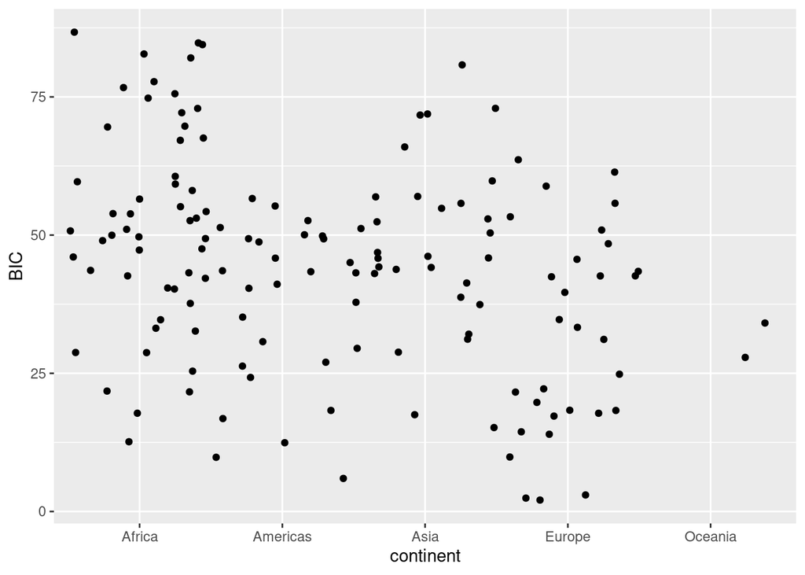

```r
glanced %>%
  unnest(glance) %>%
  ggplot(aes(continent, BIC)) +
    geom_jitter(width = 0.5)
```

```r
mtcars %>%
  group_by(cyl) %>%
  summarise(q = list(quantile(mpg)))
```

| cyl | q |
| --- | --- |
| 4 |  |
| 6 |  |
| 8 |  |

- We can unpack the listed column using `unnest()`.

```r
mtcars %>%
  group_by(cyl) %>%
  summarise(q = list(quantile(mpg))) %>%
  unnest()
```

| cyl | q |
| --- | --- |
| 4 | 21.40 |
| 4 | 22.80 |
| 4 | 26.00 |
| 4 | 30.40 |
| 4 | 33.90 |
| 6 | 17.80 |
| 6 | 18.65 |
| 6 | 19.70 |
| 6 | 21.00 |
| 6 | 21.40 |

[output cut: 5 more lines]